# Introduction to R and RStudio

Part 1: Basics (Follow Along in RStudio)

Dr. Jomana Bashatah

## Learning Outcomes

What you will learn in this session:

- How to install R and RStudio
- What is the windows layout of RStudio
- How to setup RStudio
- How to create a project (folder) in RStudio
- How to use major functionalities of RStudio
- How to extend R’s functionality with R-packages
- Which packages you should install for this course
- Data types and data objects in R
- How very big and very small numbers can be displayed

## Install and Setup R and RStudio

A typical setup to work with R consists of two components:

- **The R Console** which executes R code
- **An integrated development environment (IDE)** such as RStudio

You can download and install R and RStudio by following the steps in:

https://ise423-25.blogspot.com/2025/09/installing-r-and-rstudio-complete-step.html

## RStudio - Integrated Development Environment (IDE)

RStudio provides a user-friendly interface with four main panes:

- **Source Editor** (top-left): Write and edit R scripts
- **Console** (bottom-left): Execute R commands directly
- **Environment/History** (top-right): View variables and command history
- **Files/Plots/Packages/Help** (bottom-right): Manage files, view plots, install packages

[figure not shown]

RStudio Window

## Recommended RStudio Settings

### Essential Setup Steps:

1. **Do not Restore .RData into workspace at startup:**
   - Go to Tools → Global Options
   - Uncheck “Restore .RData into workspace at startup”
2. **Work with R Projects:**
   - This assigns a directory on your hard drive to your R analysis
   - File → New Project

## R Packages

R Packages extend R’s functionality. They have to be installed only once:

```r
# Install packages using Tools -> Install Packages... or:
install.packages(c("tidyverse", "rio"))
```

After installation they need to be loaded every new R script:

```r
library(rio)
library(tidyverse)
```

Please install these packages soon:

- **tidyverse**: supports easy data processing
- **rio**: allows loading various data resources with one import() command
- **janitor**: provides functionality to clean data and rename variable names
- **tidymodels**: streamlines data engineering and machine learning tasks
- **kableExtra**: supports rendering tables in HTML
- **shiny**: needed together with the *learnr* package for interactive exercises

## Example: The rio and tidyverse Package

```r
library(rio); library(tidyverse)

DataHousing = import("Data/HousingData.csv") |>
  select(Price=price, Sqft=sqft_living,
         Bedrooms=bedrooms, Waterfront=waterfront)

print(DataHousing[1:3,])
```

```
   Price Sqft Bedrooms Waterfront
1 221900 1180        3         no
2 538000 2570        3         no
3 180000  770        2         no
```

**Note:** `import()` requires rio package; `select()` requires tidyverse package

## Data Types & Data Objects Overview

### Data Types: What can R store?

- **numerical** (num)
- **character** (chr)
- **factor**
- **logic**

### Data Objects: What containers does R use?

- **single entry** - single variable
- **list of entries** - vectors
- **table** - dataframe and tibble
- **advanced objects** - plots, models, prediction results

## Data Types

- Main
- Numerical
- Character
- Factor
- Logic
- Truth Table
- **Numerical Data Type (num)**: Numerical values (e.g., 1, 523, 3.45) used for calculation. ZIP-Codes are NOT numerical data type.
- **Character Data Type (chr)**: Storing sequence of characters, numbers, and/or symbols (e.g. first/last names, street addresses, Zip-codes)
- **Factor Data Type (factor)**: A factor is an R data type that stores categorical data in an effective way. factor data types are also required by many classification models in R.
- **Logic Data Type (logic)**: A data type that stores the logic states TRUE and FALSE is called a logic object (sometimes called Boolean)

Numerical values are used for calculations (therefore ZIP-Codes are not numerical). Numerical data can be discrete (integer) or continuous (double).

```r
A = as.integer(2)
B = as.integer(3)
str(A)  # str() returns structure of a variable
```

```
 int 2
```

```r
C = 1.23
str(C)
```

```
 num 1.23
```

```r
print(A * C)
```

```
[1] 2.46
```

```r
A^B
```

```
[1] 8
```

```r
A/B  # Returns num type
```

```
[1] 0.6666667
```

**Note:** What is called a “character” in R is often called a “string” in other programming languages.

Character data types must be surrounded by quotes:

```r
MyText = "Hello world!"
print(MyText)
```

```
[1] "Hello world!"
```

Character variables can be concatenated with the `cat()` command:

```r
FirstName = "Jomana"
LastName = "Bashatah"
cat(FirstName, LastName)  # R adds a space automatically
```

```
Jomana Bashatah
```

A factor stores categorical data efficiently. Categorical data are character type data covering a few categories such as hair color (blonde, brown, red, black). They can be coded with numbers (e.g., 1-5 for hair color) and use less memory.

```r
People=tribble(~Name,~Sex,
                  "John", "male",
                  "Jane", "female",
                  "Mia", "female",
                  "Brid", "female",
                  "Greg", "male")
print(People)
```

```
# A tibble: 5 × 2
  Name  Sex
  <chr> <chr>
1 John  male
2 Jane  female
3 Mia   female
4 Brid  female
5 Greg  male
```

Logic variables store TRUE and FALSE. They can be combined with and/or. Internally TRUE is stored as 1 and FALSE is stored as 0.

```r
IsConcertGood = FALSE
IsCompanyGood = TRUE
cat("Is the concert good?", IsConcertGood, "Is the company good?", IsCompanyGood)
```

```
Is the concert good? FALSE Is the company good? TRUE
```

```r
IsEveningAmazing=IsConcertGood & IsCompanyGood
cat("Is the evening amazing?", IsEveningAmazing)
```

```
Is the evening amazing? FALSE
```

```r
IsEveningGood = IsConcertGood | IsCompanyGood  # | stands for "or"
cat("Is the evening good?", IsEveningGood)
```

```
Is the evening good? TRUE
```

```r
IsConcertGood+IsCompanyGood+17
```

```
[1] 18
```

| R object A | R object B | A & B | A \| B |
| --- | --- | --- | --- |
| TRUE | TRUE | TRUE | TRUE |
| TRUE | FALSE | FALSE | TRUE |
| FALSE | TRUE | FALSE | TRUE |
| FALSE | FALSE | FALSE | FALSE |

## Data Objects

- **Single Value Object**: Stores just one value
- **Vector Object**: Stores a list of values
- **Data Frame (Tibble) Object**: Table-like structure
- **List Object**: (not covered in this course)
- **Advanced Objects**: plots, models, recipes

## Single Value Object

Object stores a single value:

```r
A = 123.768
B = 3
C = "Hello World"
IsLifeGood = TRUE
```

## Vector Objects

A vector object stores a list of values (numerical, character, factor, or logic).

**Example:** Weather during the last three days in Stattown:

```r
VecTemp = c(70, 68, 55)
VecWindSpeed = c("low", "low", "high")
VecIsSunny = c(TRUE, TRUE, FALSE)
```

Vector objects can be used as arguments for an R command to calculate

```r
MeanForecTemp=mean(VecTemp)
cat("The average forecasted temperature is", MeanForecTemp)
```

```
The average forecasted temperature is 64.33333
```

```r
ForecDays=length(VecTemp)
cat("The forecast is for", ForecDays, "days.")
```

```
The forecast is for 3 days.
```

## Data Frames (Tibbles)

A data frame is similar to an Excel table:

| Survived | Pclass | Sex | Age | FareInPounds |
| --- | --- | --- | --- | --- |
| 0 | 3 | male | 22 | 7.2500 |
| 1 | 1 | female | 38 | 71.2833 |
| 1 | 3 | female | 26 | 7.9250 |
| 1 | 1 | female | 35 | 53.1000 |
| 0 | 3 | male | 35 | 8.0500 |

## Extracting Vectors and Performing Calculations

### Numerical Vectors

```r
library(rio); library(tidyverse)
DataTitanic = import("Data/Titanic.csv")
```

```r
VecFareInPounds = DataTitanic$FareInPounds
AvgFare = mean(VecFareInPounds)
cat("The average fare of Titanic passengers was:", AvgFare, "British Pounds")
```

```
The average fare of Titanic passengers was: 32.30542 British Pounds
```

## Extracting Vectors and Performing Calculations

### Logical Vectors

```r
DataTitanic$Survived = as.logical(DataTitanic$Survived)
str(DataTitanic)
```

```
'data.frame':   887 obs. of  8 variables:
 $ Survived             : logi  FALSE TRUE TRUE TRUE FALSE FALSE ...
 $ Pclass               : int  3 1 3 1 3 3 1 3 3 2 ...
 $ Name                 : chr  "Mr. Owen Harris Braund" "Mrs. John Bradley Cumings" "Miss. Laina Heikkinen" "Mrs. Jacques Heath Futrelle" ...
 $ Sex                  : chr  "male" "female" "female" "female" ...
 $ Age                  : num  22 38 26 35 35 27 54 2 27 14 ...
 $ SiblingsSpousesAboard: int  1 1 0 1 0 0 0 3 0 1 ...
 $ ParentsChildrenAboard: int  0 0 0 0 0 0 0 1 2 0 ...
 $ FareInPounds         : num  7.25 71.28 7.92 53.1 8.05 ...
```

```r
SurvRate = mean(DataTitanic$Survived)
cat("The average survival rate of Titanic passengers was:", SurvRate)
```

```
The average survival rate of Titanic passengers was: 0.3855693
```

## Data Frames vs. Tibbles

A tibble is a more advanced sub-type of a data frame. Convert with `as_tibble()`:

### Key Differences:

A few of the differences between data frames and tibbles:

1. A data frame outputs all its rows and columns by default. A tibble outputs only the first 10 rows and the variables that fit on the screen but provides information about omitted variables and rows.
2. A data frame can have row names, while a tibble cannot.
3. In R version <4.1 a data frame converts all character values to factor type. This conversion was often confusing and annoying. In contrast, a tibble only coerces character values into factor on demand. Since R version 4.1 regular data frames behave the same as tibbles.

## Summary: Data Types and Objects

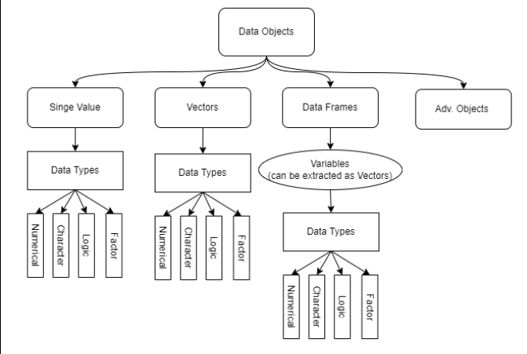

## How Are Very Big Numbers Presented

The GDP for 2021 in the US was $22,996,086,000,000 (rounded to millions)

$$\begin{align}
GDP &= 2.2996086 \cdot 10000000000000 \\
&\Longleftrightarrow \\
GDP &= 2.2996086 \cdot 10 \cdot 10 \cdot 10 \cdot 10 \cdot 10 \cdot 10 \cdot 10 \cdot 10 \cdot 10 \cdot 10 \cdot 10 \cdot 10 \cdot 10 \\
&\Longleftrightarrow \\
GDP &= 2.2996086 \cdot 10^{13}
\end{align}$$

**What R does:**

```r
GDPUS = 22996086000000
print(GDPUS)
```

```
[1] 2.299609e+13
```

## How Are Very Small Numbers Presented

- main
- Why?

The probability of getting struck by lightning in the US is about 0.000000000365 on any randomly chosen day.

$$\begin{align}
ProbLight &= \frac{3.65}{10000000000} \\
&\Longleftrightarrow \\
ProbLight &= \frac{3.65}{10 \cdot 10 \cdot 10 \cdot 10 \cdot 10 \cdot 10 \cdot 10 \cdot 10 \cdot 10 \cdot 10} \\
&\Longleftrightarrow \\
ProbLight &= \frac{3.65}{10^{10}} \\
&\Longleftrightarrow \\
ProbLight &= 3.65 \cdot 10^{-10}
\end{align}$$

### What R Does

```r
ProbStruck = 0.000000000365
cat("Probability to get struck by lightning on an avg. day:", ProbStruck)
```

```
Probability to get struck by lightning on an avg. day: 3.65e-10
```